# DATA 607 Week 02 - SQL and R

Kavya Beheraj

February 11, 2018

### **Assignment**

Choose six recent popular movies. Ask at least five people that you know (friends, family, classmates, imaginary friends) to rate each of these movies that they have seen on a scale of 1 to 5. Take the results (observations) and store them in a SQL database. Load the information into an R dataframe.

Your deliverables should include your SQL scripts and your R Markdown code, posted to GitHub.

### **Process**

1. Collect and clean data
2. Import data into mySQL
3. Connect R to MySQL
4. Load mySQL table into R dataframe
5. Question: Which movies were the highest and lowest rated?

##### **Files needed to re-create my process:**

1. Download **“movie-ratings.csv”**, which contains the cleaned data I collected in Step 1 below.
2. Download and run **“movieratings.sql”** in mySQL Workbench to import the CSV into a mySQL database.
   - **Note:** On line 12 of the “movieratings.sql” file, remember to replace the file path with the location you saved “movie-ratings.csv”.
3. Install the following packages in R:
   - **dplyr** – “RMySQL” package
   - **tidyverse** – “ggplot2” package

```r
install.packages("tidyverse", repos = "http://cran.us.r-project.org")
install.packages("dplyr", repos = "http://cran.us.r-project.org")
library(RMySQL)
```

```r
library("ggplot2")
```

### **1 | Collect and clean data**

As part of this assignment, I chose six recent popular movies and asked five friends to rate each of the movies they saw on a scale of 1 to 5. These are the movies I chose:

1. [*Star Wars: The Last Jedi* (2017)](http://www.imdb.com/title/tt2527336/)
2. [*Get Out* (2017)](http://www.imdb.com/title/tt5052448/)
3. [*Wonder Woman* (2017)](http://www.imdb.com/title/tt0451279/)
4. [*Coco* (2017)](http://www.imdb.com/title/tt2380307/)
5. [*Hidden Figures* (2016)](http://www.imdb.com/title/tt4846340/)
6. [*The Shape of Water* (2017)](http://www.imdb.com/title/tt5580390/)

(*Hidden Figures* was an accident – I intended to only include movies from 2017.)

I then created [**this Google Form**](https://docs.google.com/forms/d/e/1FAIpQLSfo4LjyG84L3ins_sXhJIcKzTr27jCHrFCJ3tR8Aefi2pPfGQ/viewform?usp=sf_link) to easily collect ratings from my friends and export them in a CSV file.

I ended up with a **raw CSV file** of responses that needed some cleaning to be best manipulated by mySQL. **Here is the cleaned file**, which includes the following three columns:

- **submitted** – the date and time that each individual submitted the Google Form.
- **movie** – the name of the movie being rated.
- **rating** – the rating each individual gave the movie, on a scale of 1 to 5.

### **2 | Import data into mySQL**

I then put together a **mySQL script** to:

- Create a new database called **“movies”**.
- Create a new empty table within “movies” called **“movieratings”** that has columns for “submitted”, “movie”, and “rating”.
- Load the CSV responses file into the empty “movieratings” table.

### **3 | Connect R to MySQL**

I used the **“dbConnect”** function built into RMySQL to connect R to mySQL.

[Here’s an overview](https://www.r-bloggers.com/accessing-mysql-through-r/) of the steps I took to connect both platforms.

```r
movies = dbConnect(MySQL(), user='root', password='JHG%*spr^t8g', dbname='movies', host='127.0.0.1')
```

### **4 | Load mySQL table into R dataframe**

To load “movieratings” into an R dataframe, I used the “dbSendQuery” function to select the table, then imported it using “fetch.”

```r
dbListTables(movies)
```

```
## [1] "movieratings"
```

```r
retrieve = dbSendQuery(movies, "select * from movieratings")

moviesimported = fetch(retrieve, n=-1)

head(moviesimported)
```

```
##                    submitted                    movie rating
## 1 2018/02/03 10:55:29 PM EST Star Wars: The Last Jedi      4
## 2 2018/02/04 12:05:53 AM EST Star Wars: The Last Jedi      5
## 3  2018/02/04 8:39:42 AM EST Star Wars: The Last Jedi      5
## 4  2018/02/06 6:09:06 PM EST Star Wars: The Last Jedi      5
## 5 2018/02/03 10:55:29 PM EST                  Get Out      4
## 6 2018/02/04 12:05:53 AM EST                  Get Out      3
```

### **5 | Question: Which movies were the highest and lowest rated?**

I found that *Star Wars: The Last Jedi* was rated the highest among my friends at 4.75, while *Hidden Figures* was rated the lowest at 3.50.

In retrospect, I’m sure there has to be a more efficient way of answering my question – perhaps a script, since I had many repeating actions. I’ll continue exploring!

I went through the following steps to identify which movie was the highest and lowest rated in my data:

- Created subsets of the ratings by movie.

```r
starwars <- subset(moviesimported, moviesimported$movie=="Star Wars: The Last Jedi", select = c(movie, rating))

getout <- subset(moviesimported, moviesimported$movie=="Get Out", select = c(movie, rating))

wonderwoman <- subset(moviesimported, moviesimported$movie=="Wonder Woman", select = c(movie, rating))

coco <- subset(moviesimported, moviesimported$movie=="Coco", select = c(movie, rating))

shapeofwater <- subset(moviesimported, moviesimported$movie=="The Shape of Water", select = c(movie, rating))

hiddenfigures <- subset(moviesimported, moviesimported$movie=="Hidden Figures", select = c(movie, rating))
```

```r
starwarsavg <- mean(starwars$rating)
getoutavg <- mean(getout$rating)
wonderwomanavg <- mean(wonderwoman$rating)
cocoavg <- mean(coco$rating)
shapeofwateravg <- mean(coco$rating)
hiddenfiguresavg <- mean(hiddenfigures$rating)
```

- Created a dataframe “movie_avg.data” that brought together the average ratings.

```r
rating_avg <- c(starwarsavg,
getoutavg,
wonderwomanavg,
cocoavg,
shapeofwateravg,
hiddenfiguresavg)

movie <- c("Star Wars", "Get Out", "Wonder Woman", "Coco", "Shape of Water", "Hidden Figures")

movie_avg.data <- data.frame(movie, rating_avg)

movie_avg.data
```

```
##            movie rating_avg
## 1      Star Wars       4.75
## 2        Get Out       4.20
## 3   Wonder Woman       4.00
## 4           Coco       4.00
## 5 Shape of Water       4.00
## 6 Hidden Figures       3.50
```

- Plotted the dataframe in a quick plot.

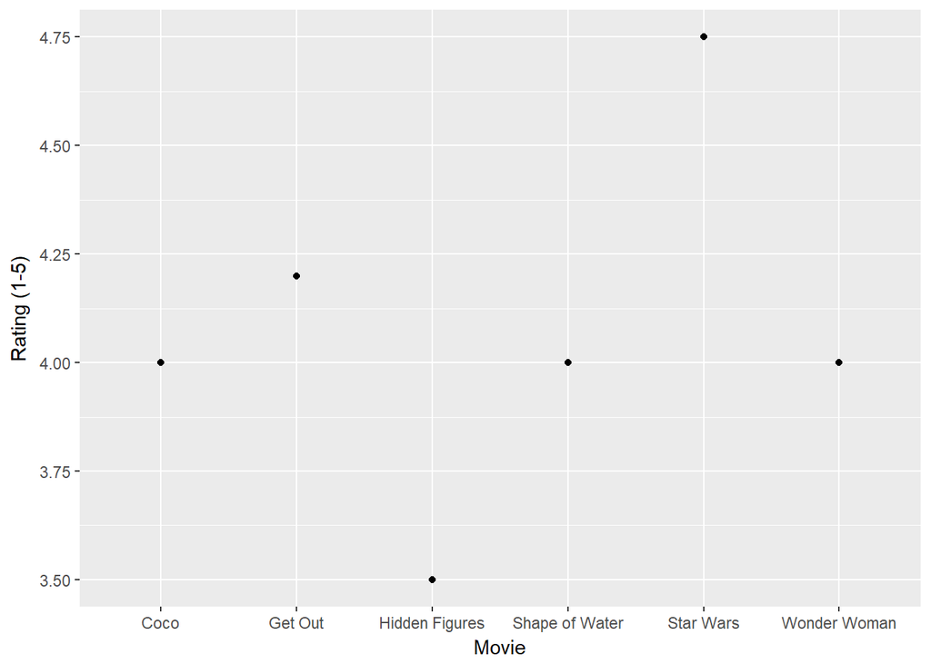

```r
qplot(movie_avg.data$movie, movie_avg.data$rating_avg, xlab = "Movie", ylab = "Rating (1-5)")
```